# Chapter 4: Column Deep Dive

**Purpose:** Analyze each column in detail with distribution analysis, value validation, and transformation recommendations.

**What you'll learn:**

- How to validate value ranges for different column types
- How to interpret distribution shapes (skewness, kurtosis)
- When and why to apply transformations (log, sqrt, capping)
- How to detect zero-inflation and handle it

**Outputs:**

- Value range validation results
- Per-column distribution visualizations with statistics
- Skewness/kurtosis analysis with transformation recommendations
- Zero-inflation detection
- Type confirmation/override capability
- Updated exploration findings

## 4.1 Load Previous Findings

**Show/Hide Code**

```python
from customer_retention.analysis.notebook_progress import track_and_export_previous

track_and_export_previous("04_column_deep_dive.ipynb")

import numpy as np
import pandas as pd
import plotly.graph_objects as go
from scipy import stats

from customer_retention.analysis.auto_explorer import ExplorationFindings, RecommendationRegistry
from customer_retention.analysis.visualization import ChartBuilder, console, display_figure, display_table
from customer_retention.core.config.column_config import ColumnType
from customer_retention.core.config.experiments import (
    FINDINGS_DIR,
)
from customer_retention.stages.profiling import (
    CategoricalDistributionAnalyzer,
    DistributionAnalyzer,
    TemporalAnalyzer,
    TemporalGranularity,
    TransformationType,
)
from customer_retention.stages.validation import DataValidator, RuleGenerator
```

**Show/Hide Code**

```python
from customer_retention.analysis.auto_explorer import load_notebook_findings

FINDINGS_PATH, _namespace, dataset_name = load_notebook_findings("04_column_deep_dive.ipynb")
print(f"Using: {FINDINGS_PATH}")

findings = ExplorationFindings.load(FINDINGS_PATH)
print(f"\nLoaded findings for {findings.column_count} columns from {findings.source_path}")

# Warn if this is event-level data (should run 01d first)
if findings.is_time_series and "_aggregated" not in FINDINGS_PATH:
    ts_meta = findings.time_series_metadata
    print("\n\u26a0\ufe0f  WARNING: This appears to be EVENT-LEVEL data")
    print(f"   Entity: {ts_meta.entity_column}, Time: {ts_meta.time_column}")
    print("   Recommendation: Run 01d_event_aggregation.ipynb first to create entity-level data")
```

```
Using: /Users/Vital/python/CustomerRetention/experiments/runs/email-6301db6c/datasets/customer_emails/findings/customer_emails_aggregated_findings.yaml
```

```
Loaded findings for 217 columns from /Users/Vital/python/CustomerRetention/experiments/runs/email-6301db6c/data/bronze/customer_emails_aggregated
```

## 4.2 Load Source Data

**Show/Hide Code**

```python
# Load data - handle aggregated data (parquet or Delta Lake)
from pathlib import Path

from customer_retention.analysis.auto_explorer.active_dataset_store import load_active_dataset
from customer_retention.stages.temporal import TEMPORAL_METADATA_COLS

# For aggregated data, load directly from the source path
if "_aggregated" in FINDINGS_PATH:
    source_path = Path(findings.source_path)
    if not source_path.is_absolute():
        source_path = Path("..") / source_path
    if source_path.is_dir():
        from customer_retention.integrations.adapters.factory import get_delta
        df = get_delta(force_local=True).read(str(source_path))
    elif source_path.is_file():
        df = pd.read_parquet(source_path)
    else:
        df = load_active_dataset(_namespace, dataset_name)
    data_source = f"aggregated:{source_path.name}"
else:
    # Standard loading for event-level or entity-level data
    df = load_active_dataset(_namespace, dataset_name)
    data_source = dataset_name

print(f"Loaded data from: {data_source}")
print(f"Shape: {df.shape}")

charts = ChartBuilder()

# Initialize recommendation registry for this exploration
registry = RecommendationRegistry()
registry.init_bronze(findings.source_path)

# Find target column for Gold layer initialization
target_col = next((name for name, col in findings.columns.items() if col.inferred_type == ColumnType.TARGET), None)
if target_col:
    registry.init_gold(target_col)

# Find entity column for Silver layer initialization
entity_col = next((name for name, col in findings.columns.items() if col.inferred_type == ColumnType.IDENTIFIER), None)
if entity_col:
    registry.init_silver(entity_col)

print(f"Initialized recommendation registry (Bronze: {findings.source_path})")
```

```
Loaded data from: aggregated:customer_emails_aggregated
Shape: (4998, 217)
Initialized recommendation registry (Bronze: /Users/Vital/python/CustomerRetention/experiments/runs/email-6301db6c/data/bronze/customer_emails_aggregated)
```

## 4.3 Value Range Validation

**📖 Interpretation Guide:**

- **Percentage fields** (rates): Should be 0-100 or 0-1 depending on format
- **Binary fields**: Should only contain 0 and 1
- **Count fields**: Should be non-negative integers
- **Amount fields**: Should be non-negative (unless refunds are possible)

**What to Watch For:**

- Rates > 100% suggest measurement or data entry errors
- Negative values in fields that should be positive
- Binary fields with values other than 0/1

**Actions:**

- Cap rates at 100 if they exceed (or investigate cause)
- Flag records with impossible negative values
- Convert binary fields to proper 0/1 encoding

**Show/Hide Code**

```python
validator = DataValidator()
range_rules = RuleGenerator.from_findings(findings)

console.start_section()
console.header("Value Range Validation")

if range_rules:
    range_results = validator.validate_value_ranges(df, range_rules)

    issues_found = []
    for r in range_results:
        detail = f"{r.invalid_values} invalid" if r.invalid_values > 0 else None
        console.check(f"{r.column_name} ({r.rule_type})", r.invalid_values == 0, detail)
        if r.invalid_values > 0:
            issues_found.append(r)

    all_invalid = sum(r.invalid_values for r in range_results)
    if all_invalid == 0:
        console.success("All value ranges valid")
    else:
        console.error(f"Found {all_invalid:,} values outside expected ranges")

        console.info("Examples of invalid values:")
        for r in issues_found[:3]:
            col = r.column_name
            if col in df.columns:
                if r.rule_type == 'binary':
                    invalid_mask = ~df[col].isin([0, 1, np.nan])
                    condition = "value not in [0, 1]"
                elif r.rule_type == 'non_negative':
                    invalid_mask = df[col] < 0
                    condition = "value < 0"
                elif r.rule_type == 'percentage':
                    invalid_mask = (df[col] < 0) | (df[col] > 100)
                    condition = "value < 0 or value > 100"
                elif r.rule_type == 'rate':
                    invalid_mask = (df[col] < 0) | (df[col] > 1)
                    condition = "value < 0 or value > 1"
                else:
                    continue

                invalid_values = df.loc[invalid_mask, col].dropna()
                if len(invalid_values) > 0:
                    examples = invalid_values.head(5).tolist()
                    console.metric(f"  {col}", f"{examples}")

                    # Add filtering recommendation
                    registry.add_bronze_filtering(
                        column=col, condition=condition, action="cap",
                        rationale=f"{r.invalid_values} values violate {r.rule_type} constraint",
                        source_notebook="04_column_deep_dive"
                    )

    console.info("Rules auto-generated from detected column types")
else:
    range_results = []
    console.info("No validation rules generated - no binary/numeric columns detected")

console.end_section()
```

VALUE RANGE VALIDATION

[OK] opened_max_180d (binary)  
[OK] clicked_max_180d (binary)  
[OK] bounced_max_180d (binary)  
[OK] opened_max_365d (binary)  
[OK] clicked_max_365d (binary)  
[OK] bounced_max_365d (binary)  
[OK] opened_max_all_time (binary)  
[OK] clicked_max_all_time (binary)  
[OK] bounced_max_all_time (binary)  
[OK] lag0_opened_max (binary)  
[OK] lag0_clicked_max (binary)  
[OK] lag0_bounced_max (binary)  
[OK] lag1_opened_max (binary)  
[OK] lag1_clicked_max (binary)  
[OK] lag1_bounced_sum (binary)  
[OK] lag1_bounced_max (binary)  
[OK] lag2_opened_max (binary)  
[OK] lag2_clicked_max (binary)  
[OK] lag2_bounced_sum (binary)  
[OK] lag2_bounced_max (binary)  
[OK] lag3_opened_max (binary)  
[OK] lag3_clicked_sum (binary)  
[OK] lag3_clicked_max (binary)  
[OK] lag3_bounced_sum (binary)  
[OK] lag3_bounced_max (binary)  
[X] opened_velocity_pct (percentage) — 137 invalid  
[X] clicked_velocity_pct (binary) — 52 invalid  
[X] send_hour_velocity_pct (percentage) — 390 invalid  
[X] bounced_velocity_pct (binary) — 18 invalid  
[X] time_to_open_hours_velocity_pct (percentage) — 155 invalid  
[X] opened_acceleration (percentage) — 41 invalid  
[X] clicked_acceleration (percentage) — 16 invalid  
[X] clicked_momentum (binary) — 48 invalid  
[X] send_hour_acceleration (percentage) — 91 invalid  
[X] bounced_acceleration (percentage) — 5 invalid  
[X] bounced_momentum (binary) — 34 invalid  
[X] time_to_open_hours_acceleration (percentage) — 39 invalid  
[OK] opened_trend_ratio (percentage)  
[OK] clicked_trend_ratio (percentage)  
[OK] send_hour_trend_ratio (percentage)  
[OK] bounced_trend_ratio (percentage)  
[X] time_to_open_hours_trend_ratio (percentage) — 6 invalid  
[OK] recency_ratio (percentage)  
[OK] opened_vs_cohort_pct (percentage)  
[OK] clicked_vs_cohort_pct (percentage)  
[OK] send_hour_vs_cohort_pct (percentage)  
[OK] bounced_vs_cohort_pct (percentage)  
[OK] time_to_open_hours_vs_cohort_pct (percentage)  
[X] Found 1,032 values outside expected ranges  
*(i) Examples of invalid values:*  
opened_velocity_pct: **[-1.0, -0.5, -1.0, -1.0, -1.0]**  
clicked_velocity_pct: **[-1.0, -1.0, -1.0, -1.0, -1.0]**  
send_hour_velocity_pct: **[-0.14285714285714285, -0.36666666666666664, -0.391304347826087, -0.19047619047619047, -0.08823529411764706]**  
*(i) Rules auto-generated from detected column types*

## 4.4 Numeric Columns Analysis

**📖 How to Interpret These Charts:**

- **Red dashed line** = Mean (sensitive to outliers)
- **Green solid line** = Median (robust to outliers)
- **Large gap between mean and median** = Skewed distribution
- **Long right tail** = Positive skew (common in count/amount data)

**📖 Understanding Distribution Metrics**

| Metric | Interpretation | Action |
| --- | --- | --- |
| **Skewness** | Measures asymmetry | \|skew\| > 1: Consider log transform |
| **Kurtosis** | Measures tail heaviness | kurt > 10: Cap outliers before transform |
| **Zero %** | Percentage of zeros | > 40%: Use zero-inflation handling |

**📖 Transformation Decision Tree:**

1. If zeros > 40% → Create binary indicator + log(non-zeros)
2. If |skewness| > 1 AND kurtosis > 10 → Cap then log
3. If |skewness| > 1 → Log transform
4. If kurtosis > 10 → Cap outliers only
5. Otherwise → Standard scaling is sufficient

**Show/Hide Code**

```
======================================================================
Column: event_count_180d
Type: numeric_discrete (Confidence: 70%)
----------------------------------------------------------------------
📊 Distribution Statistics:
   Mean: 0.639  |  Median: 0.000  |  Std: 1.009
   Range: [0.000, 11.000]
   Percentiles: 1%=0.000, 25%=0.000, 75%=1.000, 99%=4.000

📈 Shape Analysis:
   Skewness: 2.15 (Right-skewed)
   Kurtosis: 7.46 (Heavy tails/outliers)
   Zeros: 3,084 (61.7%)
   Outliers (IQR): 285 (5.7%)

🔧 Recommended Transformation: zero_inflation_handling
   Reason: Zero-inflation (61.7%) combined with high skewness (2.15)
   Priority: high
   ⚠️ Consider creating a binary indicator for zeros plus log transform of non-zero values
```

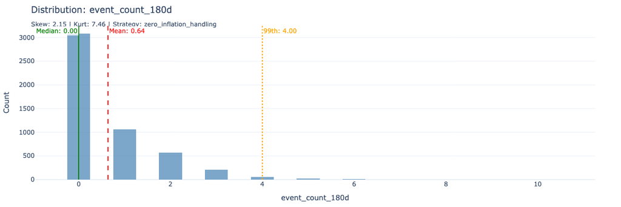

```
======================================================================
Column: event_count_365d
Type: numeric_discrete (Confidence: 70%)
----------------------------------------------------------------------
📊 Distribution Statistics:
   Mean: 1.316  |  Median: 1.000  |  Std: 1.656
   Range: [0.000, 15.000]
   Percentiles: 1%=0.000, 25%=0.000, 75%=2.000, 99%=7.000

📈 Shape Analysis:
   Skewness: 1.61 (Right-skewed)
   Kurtosis: 4.25 (Heavy tails/outliers)
   Zeros: 2,362 (47.3%)
   Outliers (IQR): 100 (2.0%)

🔧 Recommended Transformation: zero_inflation_handling
   Reason: Significant zero-inflation (47.3%)
   Priority: medium
   ⚠️ Many zero values may indicate a mixture distribution
```

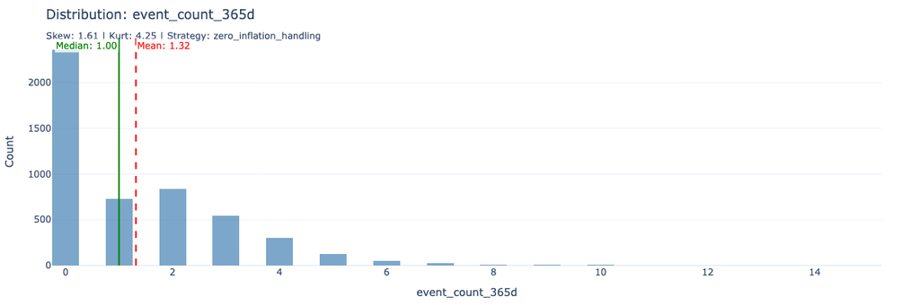

```
======================================================================
Column: event_count_all_time
Type: numeric_continuous (Confidence: 90%)
----------------------------------------------------------------------
📊 Distribution Statistics:
   Mean: 16.566  |  Median: 16.000  |  Std: 9.139
   Range: [1.000, 112.000]
   Percentiles: 1%=2.000, 25%=12.000, 75%=19.000, 99%=53.000

📈 Shape Analysis:
   Skewness: 2.61 (Right-skewed)
   Kurtosis: 16.11 (Heavy tails/outliers)
   Zeros: 0 (0.0%)
   Outliers (IQR): 298 (6.0%)

🔧 Recommended Transformation: cap_then_log
   Reason: High skewness (2.61) with significant outliers (6.0%)
   Priority: high
```

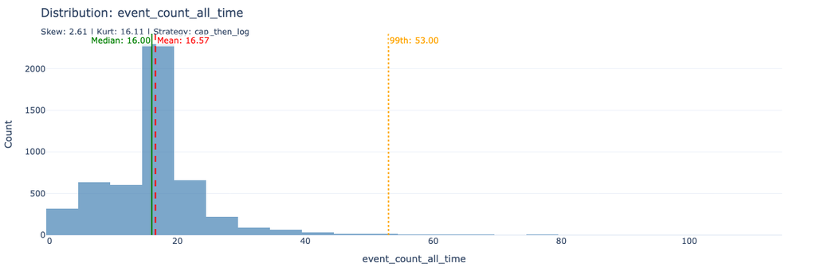

```
======================================================================
Column: opened_sum_180d
Type: numeric_discrete (Confidence: 70%)
----------------------------------------------------------------------
📊 Distribution Statistics:
   Mean: 0.152  |  Median: 0.000  |  Std: 0.424
   Range: [0.000, 4.000]
   Percentiles: 1%=0.000, 25%=0.000, 75%=0.000, 99%=2.000

📈 Shape Analysis:
   Skewness: 3.14 (Right-skewed)
   Kurtosis: 11.52 (Heavy tails/outliers)
   Zeros: 4,350 (87.0%)
   Outliers (IQR): 648 (13.0%)

🔧 Recommended Transformation: zero_inflation_handling
   Reason: Zero-inflation (87.0%) combined with high skewness (3.14)
   Priority: high
   ⚠️ Consider creating a binary indicator for zeros plus log transform of non-zero values
```

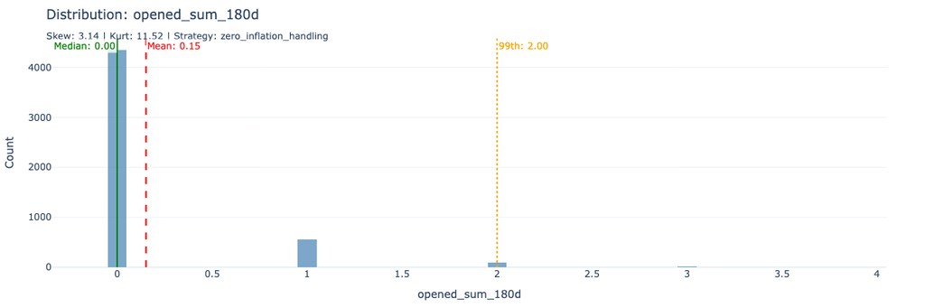

```
======================================================================
Column: opened_mean_180d
Type: numeric_discrete (Confidence: 70%)
----------------------------------------------------------------------
📊 Distribution Statistics:
   Mean: 0.232  |  Median: 0.000  |  Std: 0.366
   Range: [0.000, 1.000]
   Percentiles: 1%=0.000, 25%=0.000, 75%=0.500, 99%=1.000

📈 Shape Analysis:
   Skewness: 1.27 (Right-skewed)
   Kurtosis: 0.05 (Light tails)
   Zeros: 1,266 (66.1%)
   Outliers (IQR): 0 (0.0%)

🔧 Recommended Transformation: zero_inflation_handling
   Reason: Significant zero-inflation (66.1%)
   Priority: medium
   ⚠️ Many zero values may indicate a mixture distribution
```

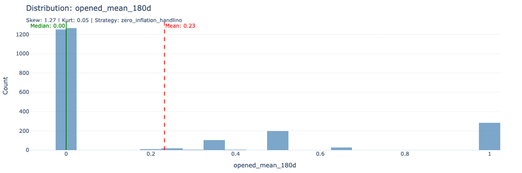

```
======================================================================
Column: opened_count_180d
Type: numeric_discrete (Confidence: 70%)
----------------------------------------------------------------------
📊 Distribution Statistics:
   Mean: 0.639  |  Median: 0.000  |  Std: 1.009
   Range: [0.000, 11.000]
   Percentiles: 1%=0.000, 25%=0.000, 75%=1.000, 99%=4.000

📈 Shape Analysis:
   Skewness: 2.15 (Right-skewed)
   Kurtosis: 7.46 (Heavy tails/outliers)
   Zeros: 3,084 (61.7%)
   Outliers (IQR): 285 (5.7%)

🔧 Recommended Transformation: zero_inflation_handling
   Reason: Zero-inflation (61.7%) combined with high skewness (2.15)
   Priority: high
   ⚠️ Consider creating a binary indicator for zeros plus log transform of non-zero values
```

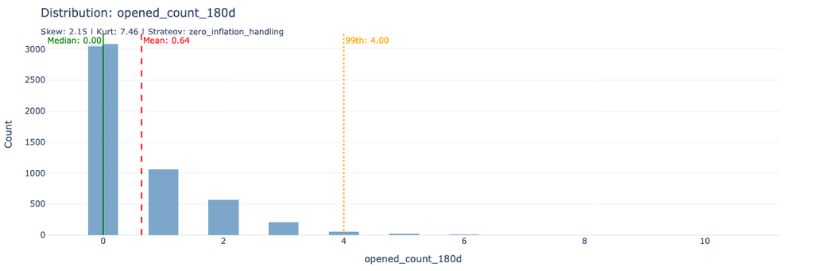

```
======================================================================
Column: clicked_sum_180d
Type: numeric_discrete (Confidence: 70%)
----------------------------------------------------------------------
📊 Distribution Statistics:
   Mean: 0.048  |  Median: 0.000  |  Std: 0.225
   Range: [0.000, 2.000]
   Percentiles: 1%=0.000, 25%=0.000, 75%=0.000, 99%=1.000

📈 Shape Analysis:
   Skewness: 4.78 (Right-skewed)
   Kurtosis: 23.72 (Heavy tails/outliers)
   Zeros: 4,767 (95.4%)
   Outliers (IQR): 231 (4.6%)

🔧 Recommended Transformation: zero_inflation_handling
   Reason: Zero-inflation (95.4%) combined with high skewness (4.78)
   Priority: high
   ⚠️ Consider creating a binary indicator for zeros plus log transform of non-zero values
```

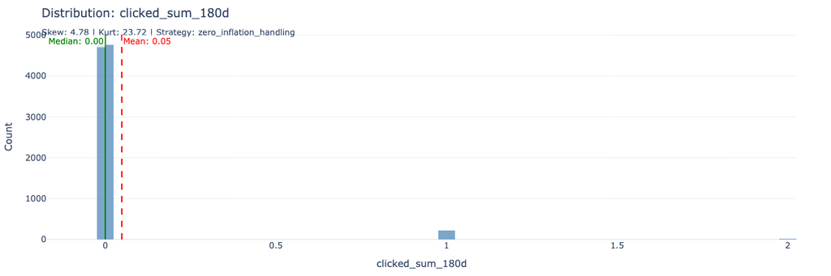

```
======================================================================
Column: clicked_mean_180d
Type: numeric_discrete (Confidence: 70%)
----------------------------------------------------------------------
📊 Distribution Statistics:
   Mean: 0.072  |  Median: 0.000  |  Std: 0.219
   Range: [0.000, 1.000]
   Percentiles: 1%=0.000, 25%=0.000, 75%=0.000, 99%=1.000

📈 Shape Analysis:
   Skewness: 3.26 (Right-skewed)
   Kurtosis: 10.01 (Heavy tails/outliers)
   Zeros: 1,683 (87.9%)
   Outliers (IQR): 231 (12.1%)

🔧 Recommended Transformation: zero_inflation_handling
   Reason: Zero-inflation (87.9%) combined with high skewness (3.26)
   Priority: high
   ⚠️ Consider creating a binary indicator for zeros plus log transform of non-zero values
```

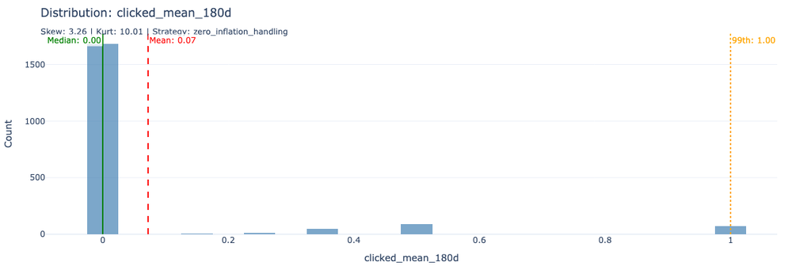

```
======================================================================
Column: clicked_count_180d
Type: numeric_discrete (Confidence: 70%)
----------------------------------------------------------------------
📊 Distribution Statistics:
   Mean: 0.639  |  Median: 0.000  |  Std: 1.009
   Range: [0.000, 11.000]
   Percentiles: 1%=0.000, 25%=0.000, 75%=1.000, 99%=4.000

📈 Shape Analysis:
   Skewness: 2.15 (Right-skewed)
   Kurtosis: 7.46 (Heavy tails/outliers)
   Zeros: 3,084 (61.7%)
   Outliers (IQR): 285 (5.7%)

🔧 Recommended Transformation: zero_inflation_handling
   Reason: Zero-inflation (61.7%) combined with high skewness (2.15)
   Priority: high
   ⚠️ Consider creating a binary indicator for zeros plus log transform of non-zero values
```

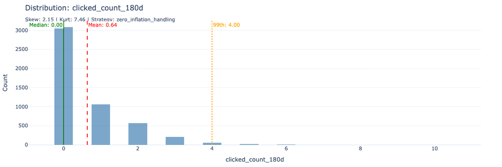

```
======================================================================
Column: send_hour_sum_180d
Type: numeric_continuous (Confidence: 90%)
----------------------------------------------------------------------
📊 Distribution Statistics:
   Mean: 8.645  |  Median: 0.000  |  Std: 13.953
   Range: [0.000, 149.000]
   Percentiles: 1%=0.000, 25%=0.000, 75%=15.000, 99%=56.030

📈 Shape Analysis:
   Skewness: 2.19 (Right-skewed)
   Kurtosis: 7.43 (Heavy tails/outliers)
   Zeros: 3,084 (61.7%)
   Outliers (IQR): 227 (4.5%)

🔧 Recommended Transformation: zero_inflation_handling
   Reason: Zero-inflation (61.7%) combined with high skewness (2.19)
   Priority: high
   ⚠️ Consider creating a binary indicator for zeros plus log transform of non-zero values
```

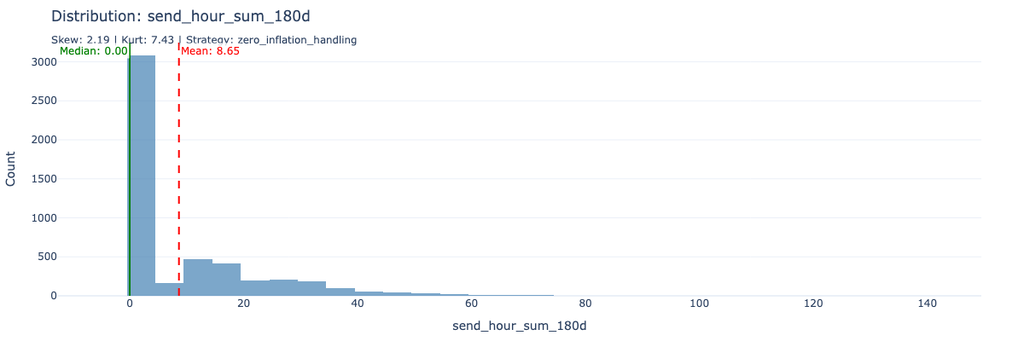

```
======================================================================
Column: send_hour_mean_180d
Type: numeric_continuous (Confidence: 90%)
----------------------------------------------------------------------
📊 Distribution Statistics:
   Mean: 13.555  |  Median: 13.500  |  Std: 3.302
   Range: [6.000, 22.000]
   Percentiles: 1%=6.000, 25%=11.333, 75%=16.000, 99%=22.000

📈 Shape Analysis:
   Skewness: 0.04 (Symmetric)
   Kurtosis: -0.10 (Light tails)
   Zeros: 0 (0.0%)
   Outliers (IQR): 0 (0.0%)

🔧 Recommended Transformation: none
   Reason: Distribution is approximately normal (skewness: 0.04)
   Priority: low
```

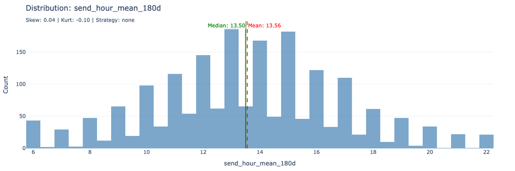

```
======================================================================
Column: send_hour_max_180d
Type: numeric_discrete (Confidence: 70%)
----------------------------------------------------------------------
📊 Distribution Statistics:
   Mean: 14.692  |  Median: 15.000  |  Std: 3.750
   Range: [6.000, 22.000]
   Percentiles: 1%=6.000, 25%=12.000, 75%=17.000, 99%=22.000

📈 Shape Analysis:
   Skewness: -0.17 (Symmetric)
   Kurtosis: -0.44 (Light tails)
   Zeros: 0 (0.0%)
   Outliers (IQR): 0 (0.0%)

🔧 Recommended Transformation: none
   Reason: Distribution is approximately normal (skewness: -0.17)
   Priority: low
```

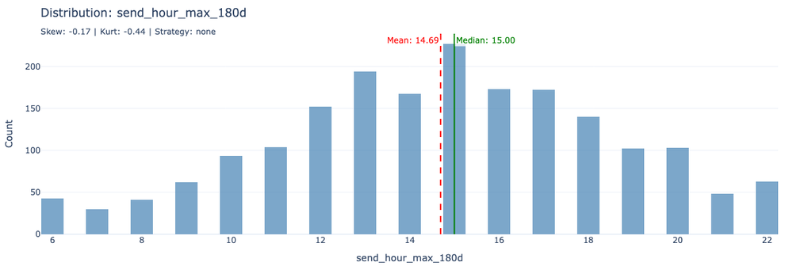

```
======================================================================
Column: send_hour_count_180d
Type: numeric_discrete (Confidence: 70%)
----------------------------------------------------------------------
📊 Distribution Statistics:
   Mean: 0.639  |  Median: 0.000  |  Std: 1.009
   Range: [0.000, 11.000]
   Percentiles: 1%=0.000, 25%=0.000, 75%=1.000, 99%=4.000

📈 Shape Analysis:
   Skewness: 2.15 (Right-skewed)
   Kurtosis: 7.46 (Heavy tails/outliers)
   Zeros: 3,084 (61.7%)
   Outliers (IQR): 285 (5.7%)

🔧 Recommended Transformation: zero_inflation_handling
   Reason: Zero-inflation (61.7%) combined with high skewness (2.15)
   Priority: high
   ⚠️ Consider creating a binary indicator for zeros plus log transform of non-zero values
```

[167 more figures not shown]

```python
# Use framework's DistributionAnalyzer for comprehensive analysis
analyzer = DistributionAnalyzer()

numeric_cols = [
    name for name, col in findings.columns.items()
    if col.inferred_type in [ColumnType.NUMERIC_CONTINUOUS, ColumnType.NUMERIC_DISCRETE]
    and name not in TEMPORAL_METADATA_COLS
]

# Analyze all numeric columns using the framework
analyses = analyzer.analyze_dataframe(df, numeric_cols)
recommendations = {col: analyzer.recommend_transformation(analysis)
                   for col, analysis in analyses.items()}

for col_name in numeric_cols:
    col_info = findings.columns[col_name]
    analysis = analyses.get(col_name)
    rec = recommendations.get(col_name)

    print(f"\n{'='*70}")
    print(f"Column: {col_name}")
    print(f"Type: {col_info.inferred_type.value} (Confidence: {col_info.confidence:.0%})")
    print("-" * 70)

    if analysis:
        print("📊 Distribution Statistics:")
        print(f"   Mean: {analysis.mean:.3f}  |  Median: {analysis.median:.3f}  |  Std: {analysis.std:.3f}")
        print(f"   Range: [{analysis.min_value:.3f}, {analysis.max_value:.3f}]")
        print(f"   Percentiles: 1%={analysis.percentiles['p1']:.3f}, 25%={analysis.q1:.3f}, 75%={analysis.q3:.3f}, 99%={analysis.percentiles['p99']:.3f}")
        print("\n📈 Shape Analysis:")
        skew_label = '(Right-skewed)' if analysis.skewness > 0.5 else '(Left-skewed)' if analysis.skewness < -0.5 else '(Symmetric)'
        print(f"   Skewness: {analysis.skewness:.2f} {skew_label}")
        kurt_label = '(Heavy tails/outliers)' if analysis.kurtosis > 3 else '(Light tails)'
        print(f"   Kurtosis: {analysis.kurtosis:.2f} {kurt_label}")
        print(f"   Zeros: {analysis.zero_count:,} ({analysis.zero_percentage:.1f}%)")
        print(f"   Outliers (IQR): {analysis.outlier_count_iqr:,} ({analysis.outlier_percentage:.1f}%)")

        if rec:
            print(f"\n🔧 Recommended Transformation: {rec.recommended_transform.value}")
            print(f"   Reason: {rec.reason}")
            print(f"   Priority: {rec.priority}")
            if rec.warnings:
                for warn in rec.warnings:
                    print(f"   ⚠️ {warn}")

    # Create enhanced histogram with Plotly
    data = df[col_name].dropna()
    fig = go.Figure()

    fig.add_trace(go.Histogram(x=data, nbinsx=50, name='Distribution',
                                marker_color='steelblue', opacity=0.7))

    # Calculate mean and median
    mean_val = data.mean()
    median_val = data.median()

    # Position labels on opposite sides (left/right) to avoid overlap
    # The larger value gets right-justified, smaller gets left-justified
    mean_position = "top right" if mean_val >= median_val else "top left"
    median_position = "top left" if mean_val >= median_val else "top right"

    # Add mean line
    fig.add_vline(
        x=mean_val,
        line_dash="dash",
        line_color="red",
        annotation_text=f"Mean: {mean_val:.2f}",
        annotation_position=mean_position,
        annotation_font_color="red",
        annotation_bgcolor="rgba(255,255,255,0.8)"
    )

    # Add median line
    fig.add_vline(
        x=median_val,
        line_dash="solid",
        line_color="green",
        annotation_text=f"Median: {median_val:.2f}",
        annotation_position=median_position,
        annotation_font_color="green",
        annotation_bgcolor="rgba(255,255,255,0.8)"
    )

    # Add 99th percentile marker if there are outliers
    if analysis and analysis.outlier_percentage > 5:
        fig.add_vline(x=analysis.percentiles['p99'], line_dash="dot", line_color="orange",
                      annotation_text=f"99th: {analysis.percentiles['p99']:.2f}",
                      annotation_position="top right",
                      annotation_font_color="orange",
                      annotation_bgcolor="rgba(255,255,255,0.8)")

    transform_label = rec.recommended_transform.value if rec else "none"
    fig.update_layout(
        title=f"Distribution: {col_name}<br><sub>Skew: {analysis.skewness:.2f} | Kurt: {analysis.kurtosis:.2f} | Strategy: {transform_label}</sub>",
        xaxis_title=col_name,
        yaxis_title="Count",
        template='plotly_white',
        height=400
    )
    display_figure(fig)
```

**Show/Hide Code**

```python
# Numerical Feature Statistics Table
if numeric_cols:
    stats_data = []
    for col_name in numeric_cols:
        series = df[col_name].dropna()
        if len(series) > 0:
            stats_data.append({
                "feature": col_name,
                "count": len(series),
                "mean": series.mean(),
                "std": series.std(),
                "min": series.min(),
                "25%": series.quantile(0.25),
                "50%": series.quantile(0.50),
                "75%": series.quantile(0.75),
                "95%": series.quantile(0.95),
                "99%": series.quantile(0.99),
                "max": series.max(),
                "skewness": stats.skew(series),
                "kurtosis": stats.kurtosis(series)
            })

    stats_df = pd.DataFrame(stats_data)

    # Format for display
    display_stats = stats_df.copy()
    for col in ["mean", "std", "min", "25%", "50%", "75%", "95%", "99%", "max"]:
        display_stats[col] = display_stats[col].apply(lambda x: f"{x:.3f}")
    display_stats["skewness"] = display_stats["skewness"].apply(lambda x: f"{x:.3f}")
    display_stats["kurtosis"] = display_stats["kurtosis"].apply(lambda x: f"{x:.3f}")

    print("=" * 80)
    print("NUMERICAL FEATURE STATISTICS")
    print("=" * 80)
    display(display_stats)
```

```
================================================================================
NUMERICAL FEATURE STATISTICS
================================================================================
```

|  | feature | count | mean | std | min | 25% | 50% | 75% | 95% | 99% | max | skewness | kurtosis |
| --- | --- | --- | --- | --- | --- | --- | --- | --- | --- | --- | --- | --- | --- |
| 0 | event_count_180d | 4998 | 0.639 | 1.009 | 0.000 | 0.000 | 0.000 | 1.000 | 3.000 | 4.000 | 11.000 | 2.151 | 7.453 |
| 1 | event_count_365d | 4998 | 1.316 | 1.656 | 0.000 | 0.000 | 1.000 | 2.000 | 4.000 | 7.000 | 15.000 | 1.611 | 4.247 |
| 2 | event_count_all_time | 4998 | 16.566 | 9.139 | 1.000 | 12.000 | 16.000 | 19.000 | 30.000 | 53.000 | 112.000 | 2.612 | 16.094 |
| 3 | opened_sum_180d | 4998 | 0.152 | 0.424 | 0.000 | 0.000 | 0.000 | 0.000 | 1.000 | 2.000 | 4.000 | 3.141 | 11.507 |
| 4 | opened_mean_180d | 1914 | 0.232 | 0.366 | 0.000 | 0.000 | 0.000 | 0.500 | 1.000 | 1.000 | 1.000 | 1.267 | 0.042 |
| ... | ... | ... | ... | ... | ... | ... | ... | ... | ... | ... | ... | ... | ... |
| 174 | bounced_vs_cohort_pct | 4998 | 1.000 | 6.487 | 0.000 | 0.000 | 0.000 | 0.000 | 0.000 | 42.356 | 84.712 | 6.442 | 40.903 |
| 175 | bounced_cohort_zscore | 4998 | 0.000 | 1.000 | -0.154 | -0.154 | -0.154 | -0.154 | -0.154 | 6.375 | 12.904 | 6.442 | 40.903 |
| 176 | time_to_open_hours_vs_cohort_mean | 4998 | 0.000 | 2.340 | -0.689 | -0.689 | -0.689 | -0.689 | 4.211 | 11.014 | 28.911 | 5.341 | 37.046 |
| 177 | time_to_open_hours_vs_cohort_pct | 4998 | 1.000 | 3.396 | 0.000 | 0.000 | 0.000 | 0.000 | 7.111 | 16.983 | 42.955 | 5.341 | 37.046 |
| 178 | time_to_open_hours_cohort_zscore | 4998 | 0.000 | 1.000 | -0.294 | -0.294 | -0.294 | -0.294 | 1.800 | 4.707 | 12.356 | 5.341 | 37.046 |

179 rows × 13 columns

## 4.5 Distribution Summary & Transformation Plan

This table summarizes all numeric columns with their recommended transformations.

**Show/Hide Code**

```python
# Build transformation summary table
summary_data = []
for col_name in numeric_cols:
    analysis = analyses.get(col_name)
    rec = recommendations.get(col_name)

    if analysis and rec:
        summary_data.append({
            "Column": col_name,
            "Skewness": f"{analysis.skewness:.2f}",
            "Kurtosis": f"{analysis.kurtosis:.2f}",
            "Zeros %": f"{analysis.zero_percentage:.1f}%",
            "Outliers %": f"{analysis.outlier_percentage:.1f}%",
            "Transform": rec.recommended_transform.value,
            "Priority": rec.priority
        })

        # Add Gold transformation recommendation if not "none"
        if rec.recommended_transform != TransformationType.NONE and registry.gold:
            registry.add_gold_transformation(
                column=col_name,
                transform=rec.recommended_transform.value,
                parameters=rec.parameters,
                rationale=rec.reason,
                source_notebook="04_column_deep_dive"
            )

if summary_data:
    summary_df = pd.DataFrame(summary_data)
    display_table(summary_df)

    # Show how many transformation recommendations were added
    transform_count = sum(1 for r in recommendations.values() if r and r.recommended_transform != TransformationType.NONE)
    if transform_count > 0 and registry.gold:
        print(f"\n✅ Added {transform_count} transformation recommendations to Gold layer")
else:
    console.info("No numeric columns to summarize")
```

| Column | Skewness | Kurtosis | Zeros % | Outliers % | Transform | Priority |
| --- | --- | --- | --- | --- | --- | --- |
| event_count_180d | 2.15 | 7.46 | 61.7% | 5.7% | zero_inflation_handling | high |
| event_count_365d | 1.61 | 4.25 | 47.3% | 2.0% | zero_inflation_handling | medium |
| event_count_all_time | 2.61 | 16.11 | 0.0% | 6.0% | cap_then_log | high |
| opened_sum_180d | 3.14 | 11.52 | 87.0% | 13.0% | zero_inflation_handling | high |
| opened_mean_180d | 1.27 | 0.05 | 66.1% | 0.0% | zero_inflation_handling | medium |
| opened_count_180d | 2.15 | 7.46 | 61.7% | 5.7% | zero_inflation_handling | high |
| clicked_sum_180d | 4.78 | 23.72 | 95.4% | 4.6% | zero_inflation_handling | high |
| clicked_mean_180d | 3.26 | 10.01 | 87.9% | 12.1% | zero_inflation_handling | high |
| clicked_count_180d | 2.15 | 7.46 | 61.7% | 5.7% | zero_inflation_handling | high |
| send_hour_sum_180d | 2.19 | 7.43 | 61.7% | 4.5% | zero_inflation_handling | high |
| send_hour_mean_180d | 0.04 | -0.10 | 0.0% | 0.0% | none | low |
| send_hour_max_180d | -0.17 | -0.44 | 0.0% | 0.0% | none | low |
| send_hour_count_180d | 2.15 | 7.46 | 61.7% | 5.7% | zero_inflation_handling | high |
| bounced_sum_180d | 9.70 | 100.59 | 98.8% | 1.2% | zero_inflation_handling | high |
| bounced_mean_180d | 7.20 | 55.40 | 96.9% | 3.1% | zero_inflation_handling | high |
| bounced_count_180d | 2.15 | 7.46 | 61.7% | 5.7% | zero_inflation_handling | high |
| time_to_open_hours_sum_180d | 5.51 | 38.63 | 87.2% | 12.8% | zero_inflation_handling | high |
| time_to_open_hours_mean_180d | 1.90 | 5.01 | 1.1% | 6.2% | sqrt_transform | medium |
| time_to_open_hours_max_180d | 1.76 | 3.97 | 1.1% | 6.0% | sqrt_transform | medium |
| time_to_open_hours_count_180d | 3.14 | 11.52 | 87.0% | 13.0% | zero_inflation_handling | high |
| opened_sum_365d | 2.37 | 7.21 | 75.9% | 24.1% | zero_inflation_handling | high |
| opened_mean_365d | 1.19 | 0.43 | 54.3% | 0.0% | zero_inflation_handling | medium |
| opened_count_365d | 1.61 | 4.25 | 47.3% | 2.0% | zero_inflation_handling | medium |
| clicked_sum_365d | 3.48 | 12.93 | 90.9% | 9.1% | zero_inflation_handling | high |
| clicked_mean_365d | 3.06 | 10.07 | 82.8% | 17.2% | zero_inflation_handling | high |
| clicked_count_365d | 1.61 | 4.25 | 47.3% | 2.0% | zero_inflation_handling | medium |
| send_hour_sum_365d | 1.62 | 3.96 | 47.3% | 2.2% | zero_inflation_handling | medium |
| send_hour_mean_365d | 0.09 | 0.28 | 0.0% | 2.4% | none | low |
| send_hour_max_365d | -0.34 | -0.23 | 0.0% | 0.0% | none | low |
| send_hour_count_365d | 1.61 | 4.25 | 47.3% | 2.0% | zero_inflation_handling | medium |
| bounced_sum_365d | 6.95 | 56.96 | 97.5% | 2.5% | zero_inflation_handling | high |
| bounced_mean_365d | 6.70 | 52.39 | 95.2% | 4.8% | zero_inflation_handling | high |
| bounced_count_365d | 1.61 | 4.25 | 47.3% | 2.0% | zero_inflation_handling | medium |
| time_to_open_hours_sum_365d | 3.94 | 20.10 | 76.2% | 23.8% | zero_inflation_handling | high |
| time_to_open_hours_mean_365d | 2.25 | 9.46 | 1.1% | 4.6% | yeo_johnson | high |
| time_to_open_hours_max_365d | 1.90 | 6.19 | 1.1% | 4.0% | sqrt_transform | medium |
| time_to_open_hours_count_365d | 2.37 | 7.21 | 75.9% | 24.1% | zero_inflation_handling | high |
| opened_sum_all_time | 2.27 | 13.25 | 13.4% | 2.1% | yeo_johnson | high |
| opened_mean_all_time | 0.38 | 0.73 | 13.4% | 0.7% | none | low |
| opened_count_all_time | 2.61 | 16.11 | 0.0% | 6.0% | cap_then_log | high |
| clicked_sum_all_time | 2.00 | 8.18 | 39.4% | 1.0% | zero_inflation_handling | high |
| clicked_mean_all_time | 1.26 | 2.33 | 39.4% | 1.0% | zero_inflation_handling | medium |
| clicked_count_all_time | 2.61 | 16.11 | 0.0% | 6.0% | cap_then_log | high |
| send_hour_sum_all_time | 2.52 | 15.09 | 0.0% | 5.1% | cap_then_log | high |
| send_hour_mean_all_time | -0.25 | 3.46 | 0.0% | 3.2% | none | low |
| send_hour_max_all_time | -1.44 | 3.55 | 0.0% | 2.4% | sqrt_transform | medium |
| send_hour_count_all_time | 2.61 | 16.11 | 0.0% | 6.0% | cap_then_log | high |
| bounced_sum_all_time | 1.92 | 4.18 | 71.1% | 1.1% | zero_inflation_handling | medium |
| bounced_mean_all_time | 7.27 | 114.67 | 71.1% | 4.8% | zero_inflation_handling | high |
| bounced_count_all_time | 2.61 | 16.11 | 0.0% | 6.0% | cap_then_log | high |

```
✅ Added 159 transformation recommendations to Gold layer
```

## 4.6 Categorical Columns Analysis

**📖 Distribution Metrics (Analogues to Numeric Skewness/Kurtosis):**

| Metric | Interpretation | Action |
| --- | --- | --- |
| **Imbalance Ratio** | Largest / Smallest category count | > 10: Consider grouping rare categories |
| **Entropy** | Diversity measure (0 = one category, higher = more uniform) | Low entropy: May need stratified sampling |
| **Top-3 Concentration** | % of data in top 3 categories | > 90%: Rare categories may cause issues |
| **Rare Category %** | Categories with < 1% of data | High %: Group into "Other" category |

**📖 Encoding Recommendations:**

- **Low cardinality (≤5)** → One-hot encoding
- **Medium cardinality (6-20)** → One-hot or Target encoding
- **High cardinality (>20)** → Target encoding or Frequency encoding
- **Cyclical (days, months)** → Sin/Cos encoding

**⚠️ Common Issues:**

- Rare categories can cause overfitting with one-hot encoding
- High cardinality + one-hot = feature explosion
- Imbalanced categories may need special handling in train/test splits

**Show/Hide Code**

```
======================================================================
Column: lifecycle_quadrant
Type: categorical_nominal (Confidence: 90%)
----------------------------------------------------------------------

📊 Distribution Metrics:
   Categories: 4
   Imbalance Ratio: 2.1x (largest/smallest)
   Entropy: 1.91 (96% of max)
   Top-1 Concentration: 33.7%
   Top-3 Concentration: 83.7%
   Rare Categories (<1%): 0

📈 Interpretation:
   ✓ HIGH DIVERSITY: Categories are relatively balanced

🔧 Recommendations:
   Encoding: one_hot
   Reason: Low cardinality (4 categories) - safe feature expansion
   Priority: low
```

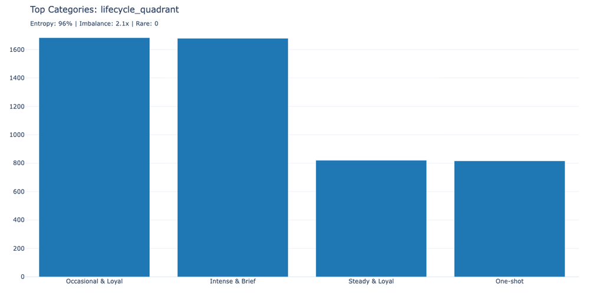

```
======================================================================
Column: recency_bucket
Type: categorical_nominal (Confidence: 90%)
----------------------------------------------------------------------

📊 Distribution Metrics:
   Categories: 5
   Imbalance Ratio: 25.1x (largest/smallest)
   Entropy: 1.64 (71% of max)
   Top-1 Concentration: 61.7%
   Top-3 Concentration: 90.3%
   Rare Categories (<1%): 0

📈 Interpretation:
   ✓ MODERATE DIVERSITY: Some category dominance but acceptable
   🟡 MODERATE IMBALANCE: Consider grouping rare categories

🔧 Recommendations:
   Encoding: one_hot
   Reason: Low cardinality (5 categories) - safe feature expansion
   Priority: low
   ⚠️ Use stratified sampling to preserve rare category representation
```

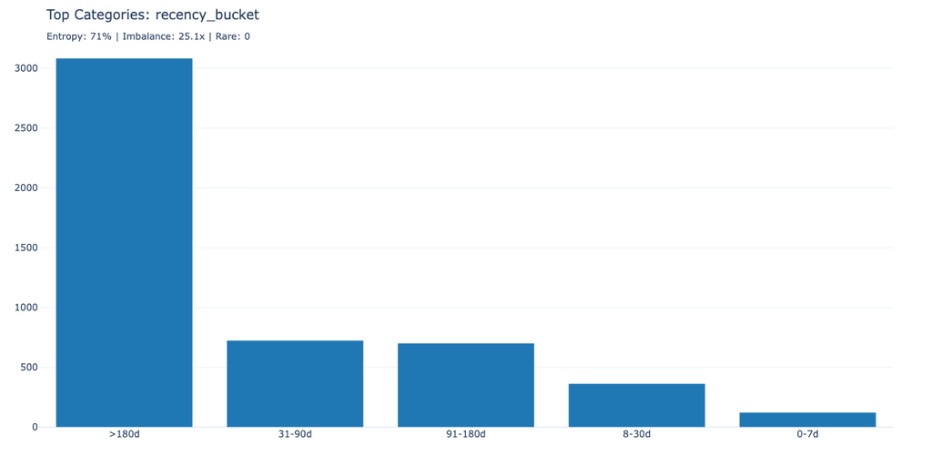

```
======================================================================
CATEGORICAL COLUMNS SUMMARY
======================================================================
```

| Column | Categories | Imbalance | Entropy | Top-3 Conc. | Rare (<1%) | Encoding |
| --- | --- | --- | --- | --- | --- | --- |
| lifecycle_quadrant | 4 | 2.1x | 96% | 83.7% | 0 | one_hot |
| recency_bucket | 5 | 25.1x | 71% | 90.3% | 0 | one_hot |

```
✅ Added 2 encoding recommendations to Gold layer
```

```python
# Use framework's CategoricalDistributionAnalyzer
cat_analyzer = CategoricalDistributionAnalyzer()

categorical_cols = [
    name for name, col in findings.columns.items()
    if col.inferred_type in [ColumnType.CATEGORICAL_NOMINAL, ColumnType.CATEGORICAL_ORDINAL, ColumnType.CATEGORICAL_CYCLICAL]
    and col.inferred_type != ColumnType.TEXT  # TEXT columns processed separately in 02a
    and name not in TEMPORAL_METADATA_COLS
]

# Analyze all categorical columns
cat_analyses = cat_analyzer.analyze_dataframe(df, categorical_cols)

# Get encoding recommendations
cyclical_cols = [name for name, col in findings.columns.items()
                 if col.inferred_type == ColumnType.CATEGORICAL_CYCLICAL]
cat_recommendations = cat_analyzer.get_all_recommendations(df, categorical_cols, cyclical_columns=cyclical_cols)

for col_name in categorical_cols:
    col_info = findings.columns[col_name]
    analysis = cat_analyses.get(col_name)
    rec = next((r for r in cat_recommendations if r.column_name == col_name), None)

    print(f"\n{'='*70}")
    print(f"Column: {col_name}")
    print(f"Type: {col_info.inferred_type.value} (Confidence: {col_info.confidence:.0%})")
    print("-" * 70)

    if analysis:
        print("\n📊 Distribution Metrics:")
        print(f"   Categories: {analysis.category_count}")
        print(f"   Imbalance Ratio: {analysis.imbalance_ratio:.1f}x (largest/smallest)")
        print(f"   Entropy: {analysis.entropy:.2f} ({analysis.normalized_entropy*100:.0f}% of max)")
        print(f"   Top-1 Concentration: {analysis.top1_concentration:.1f}%")
        print(f"   Top-3 Concentration: {analysis.top3_concentration:.1f}%")
        print(f"   Rare Categories (<1%): {analysis.rare_category_count}")

        # Interpretation
        print("\n📈 Interpretation:")
        if analysis.has_low_diversity:
            print("   ⚠️ LOW DIVERSITY: Distribution dominated by few categories")
        elif analysis.normalized_entropy > 0.9:
            print("   ✓ HIGH DIVERSITY: Categories are relatively balanced")
        else:
            print("   ✓ MODERATE DIVERSITY: Some category dominance but acceptable")

        if analysis.imbalance_ratio > 100:
            print("   🔴 SEVERE IMBALANCE: Rarest category has very few samples")
        elif analysis.is_imbalanced:
            print("   🟡 MODERATE IMBALANCE: Consider grouping rare categories")

        # Recommendations
        if rec:
            print("\n🔧 Recommendations:")
            print(f"   Encoding: {rec.encoding_type.value}")
            print(f"   Reason: {rec.reason}")
            print(f"   Priority: {rec.priority}")

            if rec.preprocessing_steps:
                print("   Preprocessing:")
                for step in rec.preprocessing_steps:
                    print(f"      • {step}")

            if rec.warnings:
                for warn in rec.warnings:
                    print(f"   ⚠️ {warn}")

    # Visualization
    value_counts = df[col_name].value_counts()
    subtitle = f"Entropy: {analysis.normalized_entropy*100:.0f}% | Imbalance: {analysis.imbalance_ratio:.1f}x | Rare: {analysis.rare_category_count}" if analysis else ""
    fig = charts.bar_chart(
        value_counts.head(10).index.tolist(),
        value_counts.head(10).values.tolist(),
        title=f"Top Categories: {col_name}<br><sub>{subtitle}</sub>"
    )
    display_figure(fig)

# Summary table and add recommendations to registry
if cat_analyses:
    print("\n" + "=" * 70)
    print("CATEGORICAL COLUMNS SUMMARY")
    print("=" * 70)
    summary_data = []
    for col_name, analysis in cat_analyses.items():
        rec = next((r for r in cat_recommendations if r.column_name == col_name), None)
        summary_data.append({
            "Column": col_name,
            "Categories": analysis.category_count,
            "Imbalance": f"{analysis.imbalance_ratio:.1f}x",
            "Entropy": f"{analysis.normalized_entropy*100:.0f}%",
            "Top-3 Conc.": f"{analysis.top3_concentration:.1f}%",
            "Rare (<1%)": analysis.rare_category_count,
            "Encoding": rec.encoding_type.value if rec else "N/A"
        })

        # Add encoding recommendation to Gold layer
        if rec and registry.gold:
            registry.add_gold_encoding(
                column=col_name,
                method=rec.encoding_type.value,
                rationale=rec.reason,
                source_notebook="04_column_deep_dive"
            )

    display_table(pd.DataFrame(summary_data))

    if registry.gold:
        print(f"\n✅ Added {len(cat_recommendations)} encoding recommendations to Gold layer")
```

## 4.7 Datetime Columns Analysis

**📖 Unlike numeric transformations, datetime analysis recommends NEW FEATURES to create:**

| Recommendation Type | Purpose | Examples |
| --- | --- | --- |
| **Feature Engineering** | Create predictive features from dates | `days_since_signup`, `tenure_years`, `month_sin_cos` |
| **Modeling Strategy** | How to structure train/test | Time-based splits when trends detected |
| **Data Quality** | Issues to address before modeling | Placeholder dates (1/1/1900) to filter |

**📖 Feature Engineering Strategies:**

- **Recency**: `days_since_X` - How recent was the event? (useful for predicting behavior)
- **Tenure**: `tenure_years` - How long has customer been active? (maturity/loyalty)
- **Duration**: `days_between_A_and_B` - Time between events (e.g., signup to first purchase)
- **Cyclical**: `month_sin`, `month_cos` - Preserves that December is near January
- **Categorical**: `is_weekend`, `is_quarter_end` - Behavioral indicators

**Show/Hide Code**

```python
from customer_retention.stages.profiling.temporal_analyzer import TemporalRecommendationType

datetime_cols = [
    name for name, col in findings.columns.items()
    if col.inferred_type == ColumnType.DATETIME
    and name not in TEMPORAL_METADATA_COLS
]

temporal_analyzer = TemporalAnalyzer()

# Store all datetime recommendations grouped by type
feature_engineering_recs = []
modeling_strategy_recs = []
data_quality_recs = []
datetime_summaries = []

for col_name in datetime_cols:
    col_info = findings.columns[col_name]
    print(f"\n{'='*70}")
    print(f"Column: {col_name}")
    print(f"Type: {col_info.inferred_type.value} (Confidence: {col_info.confidence:.0%})")
    print(f"{'='*70}")

    date_series = pd.to_datetime(df[col_name], errors='coerce', format='mixed')
    valid_dates = date_series.dropna()

    print(f"\n📅 Date Range: {valid_dates.min()} to {valid_dates.max()}")
    print(f"   Nulls: {date_series.isna().sum():,} ({date_series.isna().mean()*100:.1f}%)")

    # Basic temporal analysis
    analysis = temporal_analyzer.analyze(date_series)
    print(f"   Auto-detected granularity: {analysis.granularity.value}")
    print(f"   Span: {analysis.span_days:,} days ({analysis.span_days/365:.1f} years)")

    # Growth analysis
    growth = temporal_analyzer.calculate_growth_rate(date_series)
    if growth.get("has_data"):
        print("\n📈 Growth Analysis:")
        print(f"   Trend: {growth['trend_direction'].upper()}")
        print(f"   Overall growth: {growth['overall_growth_pct']:+.1f}%")
        print(f"   Avg monthly growth: {growth['avg_monthly_growth']:+.1f}%")

    # Seasonality analysis
    seasonality = temporal_analyzer.analyze_seasonality(date_series)
    if seasonality.has_seasonality:
        print("\n🔄 Seasonality Detected:")
        print(f"   Peak months: {', '.join(seasonality.peak_periods[:3])}")
        print(f"   Trough months: {', '.join(seasonality.trough_periods[:3])}")
        print(f"   Seasonal strength: {seasonality.seasonal_strength:.2f}")

    # Get recommendations using framework
    other_dates = [c for c in datetime_cols if c != col_name]
    recommendations = temporal_analyzer.recommend_features(date_series, col_name, other_date_columns=other_dates)

    # Group by recommendation type
    col_feature_recs = [r for r in recommendations if r.recommendation_type == TemporalRecommendationType.FEATURE_ENGINEERING]
    col_modeling_recs = [r for r in recommendations if r.recommendation_type == TemporalRecommendationType.MODELING_STRATEGY]
    col_quality_recs = [r for r in recommendations if r.recommendation_type == TemporalRecommendationType.DATA_QUALITY]

    feature_engineering_recs.extend(col_feature_recs)
    modeling_strategy_recs.extend(col_modeling_recs)
    data_quality_recs.extend(col_quality_recs)

    # Display recommendations grouped by type
    if col_feature_recs:
        print("\n🛠️ FEATURES TO CREATE:")
        for rec in col_feature_recs:
            priority_icon = "🔴" if rec.priority == "high" else "🟡" if rec.priority == "medium" else "✓"
            print(f"   {priority_icon} {rec.feature_name} ({rec.category})")
            print(f"      Why: {rec.reason}")
            if rec.code_hint:
                print(f"      Code: {rec.code_hint}")

    if col_modeling_recs:
        print("\n⚙️ MODELING CONSIDERATIONS:")
        for rec in col_modeling_recs:
            priority_icon = "🔴" if rec.priority == "high" else "🟡" if rec.priority == "medium" else "✓"
            print(f"   {priority_icon} {rec.feature_name}")
            print(f"      Why: {rec.reason}")

    if col_quality_recs:
        print("\n⚠️ DATA QUALITY ISSUES:")
        for rec in col_quality_recs:
            priority_icon = "🔴" if rec.priority == "high" else "🟡" if rec.priority == "medium" else "✓"
            print(f"   {priority_icon} {rec.feature_name}")
            print(f"      Why: {rec.reason}")
            if rec.code_hint:
                print(f"      Code: {rec.code_hint}")

    # Standard extractions always available
    print("\n   Standard extractions available: year, month, day, day_of_week, quarter")

    # Store summary
    datetime_summaries.append({
        "Column": col_name,
        "Span (days)": analysis.span_days,
        "Seasonality": "Yes" if seasonality.has_seasonality else "No",
        "Trend": growth.get('trend_direction', 'N/A').capitalize() if growth.get("has_data") else "N/A",
        "Features to Create": len(col_feature_recs),
        "Modeling Notes": len(col_modeling_recs),
        "Quality Issues": len(col_quality_recs)
    })

    # === VISUALIZATIONS ===

    if growth.get("has_data"):
        fig = charts.growth_summary_indicators(growth, title=f"Growth Summary: {col_name}")
        display_figure(fig)

    chart_type = "line" if analysis.granularity in [TemporalGranularity.DAY, TemporalGranularity.WEEK] else "bar"
    fig = charts.temporal_distribution(analysis, title=f"Records Over Time: {col_name}", chart_type=chart_type)
    display_figure(fig)

    fig = charts.temporal_trend(analysis, title=f"Trend Analysis: {col_name}")
    display_figure(fig)

    yoy_data = temporal_analyzer.year_over_year_comparison(date_series)
    if len(yoy_data) > 1:
        fig = charts.year_over_year_lines(yoy_data, title=f"Year-over-Year: {col_name}")
        display_figure(fig)
        fig = charts.year_month_heatmap(yoy_data, title=f"Records Heatmap: {col_name}")
        display_figure(fig)

    if growth.get("has_data"):
        fig = charts.cumulative_growth_chart(growth["cumulative"], title=f"Cumulative Records: {col_name}")
        display_figure(fig)

    fig = charts.temporal_heatmap(date_series, title=f"Day of Week Distribution: {col_name}")
    display_figure(fig)

# === DATETIME SUMMARY ===
if datetime_summaries:
    print("\n" + "=" * 70)
    print("DATETIME COLUMNS SUMMARY")
    print("=" * 70)
    display_table(pd.DataFrame(datetime_summaries))

    # Summary by recommendation type
    print("\n📋 ALL RECOMMENDATIONS BY TYPE:")

    if feature_engineering_recs:
        print(f"\n🛠️ FEATURES TO CREATE ({len(feature_engineering_recs)}):")
        for i, rec in enumerate(feature_engineering_recs, 1):
            priority_icon = "🔴" if rec.priority == "high" else "🟡" if rec.priority == "medium" else "✓"
            print(f"   {i}. {priority_icon} {rec.feature_name}")

    if modeling_strategy_recs:
        print(f"\n⚙️ MODELING CONSIDERATIONS ({len(modeling_strategy_recs)}):")
        for i, rec in enumerate(modeling_strategy_recs, 1):
            priority_icon = "🔴" if rec.priority == "high" else "🟡" if rec.priority == "medium" else "✓"
            print(f"   {i}. {priority_icon} {rec.feature_name}: {rec.reason}")

    if data_quality_recs:
        print(f"\n⚠️ DATA QUALITY TO ADDRESS ({len(data_quality_recs)}):")
        for i, rec in enumerate(data_quality_recs, 1):
            priority_icon = "🔴" if rec.priority == "high" else "🟡" if rec.priority == "medium" else "✓"
            print(f"   {i}. {priority_icon} {rec.feature_name}: {rec.reason}")

    # Add recommendations to registry
    added_derived = 0
    added_modeling = 0

    # Add feature engineering recommendations to Silver layer (derived columns)
    if registry.silver:
        for rec in feature_engineering_recs:
            registry.add_silver_derived(
                column=rec.feature_name,
                expression=rec.code_hint or "",
                feature_type=rec.category,
                rationale=rec.reason,
                source_notebook="04_column_deep_dive"
            )
            added_derived += 1

    # Add modeling strategy recommendations to Bronze layer
    seen_strategies = set()
    for rec in modeling_strategy_recs:
        if rec.feature_name not in seen_strategies:
            registry.add_bronze_modeling_strategy(
                strategy=rec.feature_name,
                column=datetime_cols[0] if datetime_cols else "",
                parameters={"category": rec.category},
                rationale=rec.reason,
                source_notebook="04_column_deep_dive"
            )
            seen_strategies.add(rec.feature_name)
            added_modeling += 1

    print(f"\n✅ Added {added_derived} derived column recommendations to Silver layer")
    print(f"✅ Added {added_modeling} modeling strategy recommendations to Bronze layer")
```

## 4.8 Type Override (Optional)

If any column types were incorrectly inferred, you can override them here.

**Common overrides:**

- Binary columns detected as numeric → `ColumnType.BINARY`
- IDs detected as numeric → `ColumnType.IDENTIFIER`
- Ordinal categories detected as nominal → `ColumnType.CATEGORICAL_ORDINAL`

**Show/Hide Code**

```python
# === TYPE OVERRIDES ===
# Uncomment and modify to override any incorrectly inferred types
TYPE_OVERRIDES = {
    # "column_name": ColumnType.NEW_TYPE,
    # Examples:
    # "is_active": ColumnType.BINARY,
    # "user_id": ColumnType.IDENTIFIER,
    # "satisfaction_level": ColumnType.CATEGORICAL_ORDINAL,
}

if TYPE_OVERRIDES:
    print("Applying type overrides:")
    for col_name, new_type in TYPE_OVERRIDES.items():
        if col_name in findings.columns:
            old_type = findings.columns[col_name].inferred_type.value
            findings.columns[col_name].inferred_type = new_type
            findings.columns[col_name].confidence = 1.0
            findings.columns[col_name].evidence.append("Manually overridden")
            print(f"  {col_name}: {old_type} → {new_type.value}")
else:
    print("No type overrides configured.")
    print("To override a type, add entries to TYPE_OVERRIDES dictionary above.")
```

```
No type overrides configured.
To override a type, add entries to TYPE_OVERRIDES dictionary above.
```

## 4.9 Data Segmentation Analysis

**Purpose:** Determine if the dataset contains natural subgroups that might benefit from separate models.

**📖 Why This Matters:**

- Some datasets have distinct customer segments with very different behaviors
- A single model might struggle to capture patterns that vary significantly across segments
- Segmented models can improve accuracy but add maintenance complexity

**Recommendations:**

- **single_model** - Data is homogeneous; one model for all records
- **consider_segmentation** - Some variation exists; evaluate if complexity is worth it
- **strong_segmentation** - Distinct segments with different target rates; separate models likely beneficial

**Important:** This is exploratory guidance only. The final decision depends on business context, model complexity tolerance, and available resources.

**Show/Hide Code**

```
======================================================================
DATA SEGMENTATION ANALYSIS
======================================================================

🎯 Analysis Results:
   Method: kmeans
   Detected Segments: 1
   Cluster Quality Score: 0.00
   Target Variance Ratio: 0.00

📊 Segment Profiles:
   Segment 0: 4,998 records (100.0%) | Target Rate: 44.6%
```

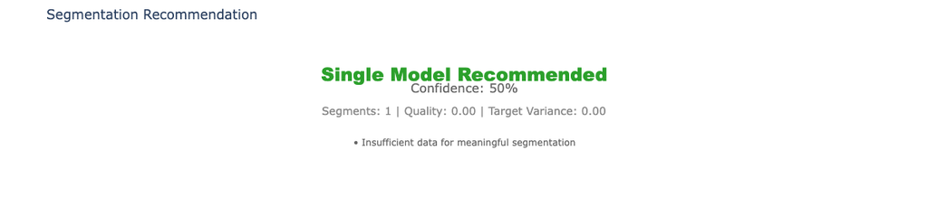

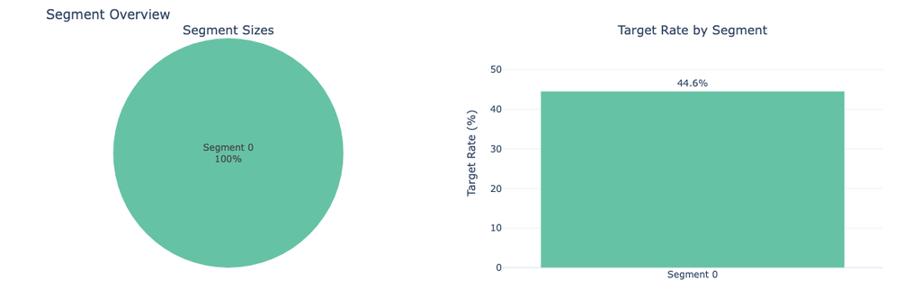

```
📝 Rationale:
   • Insufficient data for meaningful segmentation
```

```python
from customer_retention.stages.profiling import SegmentAnalyzer

# Initialize segment analyzer
segment_analyzer = SegmentAnalyzer()

# Find target column if detected
target_col = None
for col_name, col_info in findings.columns.items():
    if col_info.inferred_type == ColumnType.TARGET:
        target_col = col_name
        break

# Run segmentation analysis using numeric features
print("="*70)
print("DATA SEGMENTATION ANALYSIS")
print("="*70)

segmentation = segment_analyzer.analyze(
    df,
    target_col=target_col,
    feature_cols=numeric_cols if numeric_cols else None,
    max_segments=5
)

print("\n🎯 Analysis Results:")
print(f"   Method: {segmentation.method.value}")
print(f"   Detected Segments: {segmentation.n_segments}")
print(f"   Cluster Quality Score: {segmentation.quality_score:.2f}")
if segmentation.target_variance_ratio is not None:
    print(f"   Target Variance Ratio: {segmentation.target_variance_ratio:.2f}")

print("\n📊 Segment Profiles:")
for profile in segmentation.profiles:
    target_info = f" | Target Rate: {profile.target_rate*100:.1f}%" if profile.target_rate is not None else ""
    print(f"   Segment {profile.segment_id}: {profile.size:,} records ({profile.size_pct:.1f}%){target_info}")

# Display recommendation card
fig = charts.segment_recommendation_card(segmentation)
display_figure(fig)

# Display segment overview
fig = charts.segment_overview(segmentation, title="Segment Overview")
display_figure(fig)

# Display feature comparison if we have features
if segmentation.n_segments > 1 and any(p.defining_features for p in segmentation.profiles):
    fig = charts.segment_feature_comparison(segmentation, title="Feature Comparison Across Segments")
    display_figure(fig)

print("\n📝 Rationale:")
for reason in segmentation.rationale:
    print(f"   • {reason}")
```

## 4.10 Save Updated Findings

**Show/Hide Code**

```python
# Save updated findings back to the same file
findings.save(FINDINGS_PATH)
print(f"Updated findings saved to: {FINDINGS_PATH}")

# Save recommendations registry
recommendations_path = FINDINGS_PATH.replace("_findings.yaml", "_recommendations.yaml")
registry.save(recommendations_path)
print(f"Recommendations saved to: {recommendations_path}")

# Summary of recommendations
all_recs = registry.all_recommendations
print("\n📋 Recommendations Summary:")
print(f"   Bronze layer: {len(registry.get_by_layer('bronze'))} recommendations")
print(f"   Silver layer: {len(registry.get_by_layer('silver'))} recommendations")
print(f"   Gold layer: {len(registry.get_by_layer('gold'))} recommendations")
print(f"   Total: {len(all_recs)} recommendations")
```

```
Updated findings saved to: /Users/Vital/python/CustomerRetention/experiments/runs/email-6301db6c/datasets/customer_emails/findings/customer_emails_aggregated_findings.yaml
Recommendations saved to: /Users/Vital/python/CustomerRetention/experiments/runs/email-6301db6c/datasets/customer_emails/findings/customer_emails_aggregated_recommendations.yaml

📋 Recommendations Summary:
   Bronze layer: 3 recommendations
   Silver layer: 0 recommendations
   Gold layer: 161 recommendations
   Total: 164 recommendations
```

## Summary: What We Learned

In this notebook, we performed a deep dive analysis that included:

1. **Value Range Validation** - Validated rates, binary fields, and non-negative constraints
2. **Numeric Distribution Analysis** - Calculated skewness, kurtosis, and percentiles with transformation recommendations
3. **Categorical Distribution Analysis** - Calculated imbalance ratio, entropy, and concentration with encoding recommendations
4. **Datetime Analysis** - Analyzed seasonality, trends, and patterns with feature engineering recommendations
5. **Data Segmentation** - Evaluated if natural subgroups exist that might benefit from separate models

## Key Metrics Reference

**Numeric Columns:**

| Metric | Threshold | Action |
| --- | --- | --- |
| Skewness | \|skew\| > 1 | Log transform |
| Kurtosis | > 10 | Cap outliers first |
| Zero % | > 40% | Zero-inflation handling |

**Categorical Columns:**

| Metric | Threshold | Action |
| --- | --- | --- |
| Imbalance Ratio | > 10x | Group rare categories |
| Entropy | < 50% | Stratified sampling |
| Rare Categories | > 0 | Group into "Other" |

**Datetime Columns:**

| Finding | Action |
| --- | --- |
| Seasonality | Add cyclical month encoding |
| Strong trend | Time-based train/test split |
| Multiple dates | Calculate duration features |
| Placeholder dates | Filter or flag |

## Transformation & Encoding Summary

Review the summary tables above for:

- **Numeric**: Which columns need log transforms, capping, or zero-inflation handling
- **Categorical**: Which encoding to use and whether to group rare categories
- **Datetime**: Which temporal features to engineer based on detected patterns

## Next Steps

Continue to **02_source_integrity.ipynb** to:

- Analyze duplicate records and value conflicts
- Deep dive into missing value patterns
- Analyze outliers with IQR method
- Check data consistency
- Get cleaning recommendations

Or jump to **05_feature_opportunities.ipynb** if you want to see derived feature recommendations.

> **Save Reminder:** Save this notebook (Ctrl+S / Cmd+S) before running the next one. The next notebook will automatically export this notebook's HTML documentation from the saved file.